# F

##### I thus argue that a more reasonable explanation is that the "Fare" variable stands for the total price of a given ticket number.

```python
# As I argued above. The Fare is the fare of the ticket.
# This means that we should divide the fare by the number of the people, who share the same ticket number.
t_data["each_fare"] = t_data["Fare"]/t_data["Ticket_size"]
```

Now let us compare the unconditional "Fare" distribution.

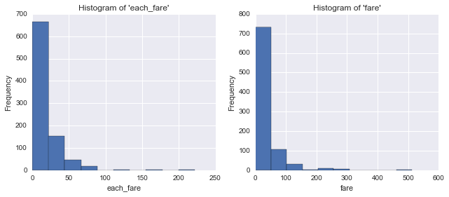

```python
plt.figure(1, figsize=(9,4))
plt.subplot(1,2,1)
ax1 = t_data["each_fare"].plot.hist()
ax1.set_title("Histogram of 'each_fare'")
ax1.set(xlabel = 'each_fare')
plt.subplot(1,2,2)
ax2 = t_data["Fare"].plot.hist()
ax2.set_title("Histogram of 'fare'")
ax2.set(xlabel = 'fare')
plt.tight_layout()
```

There are more concentrations on the left tail. Now let us compare the conditional distributions.

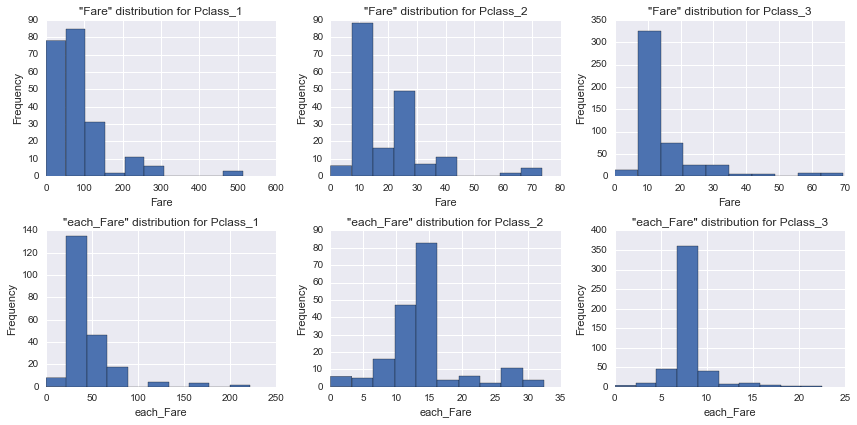

```python
fig, axes = plt.subplots(nrows=2, ncols=3)
fig.set_size_inches(w=12,h=6)
t_data.loc[t_data["Pclass"] == 1, "Fare"].plot.hist(ax=axes[0,0]);
axes[0,0].set_title('"Fare" distribution for Pclass_1'); axes[0,0].set(xlabel = 'Fare');
t_data.loc[t_data["Pclass"] == 2, "Fare"].plot.hist(ax=axes[0,1]);
axes[0,1].set_title('"Fare" distribution for Pclass_2'); axes[0,1].set(xlabel = 'Fare');
t_data.loc[t_data["Pclass"] == 3, "Fare"].plot.hist(ax=axes[0,2]);
axes[0,2].set_title('"Fare" distribution for Pclass_3'); axes[0,2].set(xlabel = 'Fare');
t_data.loc[t_data["Pclass"] == 1, "each_fare"].plot.hist(ax=axes[1,0]);
axes[1,0].set_title('"each_Fare" distribution for Pclass_1'); axes[1,0].set(xlabel = 'each_Fare');
t_data.loc[t_data["Pclass"] == 2, "each_fare"].plot.hist(ax=axes[1,1]);
axes[1,1].set_title('"each_Fare" distribution for Pclass_2'); axes[1,1].set(xlabel = 'each_Fare');
t_data.loc[t_data["Pclass"] == 3, "each_fare"].plot.hist(ax=axes[1,2]);
axes[1,2].set_title('"each_Fare" distribution for Pclass_3'); axes[1,2].set(xlabel = 'each_Fare');
plt.tight_layout()
```

As expected, the values in the upper tails for each Pclass now have more regular behaviors.

Analogously, we could have a look at the boxplot.

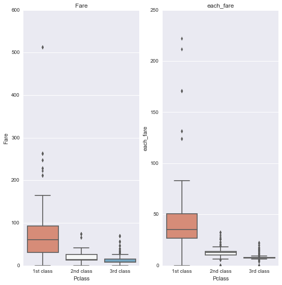

```python
plt.figure(1, figsize=(9,9))
plt.subplot(1,2,1)
ax=sns.boxplot(x="Pclass", y='Fare', data=t_data, palette='RdBu');
ax.set(title='Fare')
ax.set_xticklabels(["1st class", "2nd class", "3rd class"])
plt.subplot(1,2,2)
ax=sns.boxplot(x="Pclass", y='each_fare', data=t_data, palette='RdBu');
ax.set(title='each_fare')
ax.set_xticklabels(["1st class", "2nd class", "3rd class"])
plt.show()
# t_data.boxplot(column=['each_fare'], by='Pclass')
```

Till this stage, I have finished most of the data wrangling process.

### 3. Survival analysis

#### 3.0 Sex and survival rate.

- Did gender influence survival rate? If so, Why exactly?

I will start by drawing the survival rate conditional on Sex.

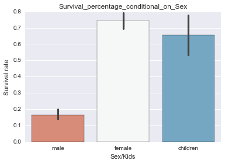

```python
plt.figure(1, figsize=(6,4))
ax=sns.barplot(x="Sex", y='Survived', data=t_data, palette='RdBu');
ax.set(xlabel='Sex/Kids', ylabel = "Survival rate", title='Survival_percentage_conditional_on_Sex')
ax.set_xticklabels(["male", "female", "children"])
plt.show()
```

```python
survival_rate_males = \
t_data.loc[(t_data["Sex"]==0) & (t_data["Survived"]==1), "Sex"].value_counts()/\
t_data.loc[(t_data["Sex"]==0), "Sex"].value_counts()

survival_rate_females = \
t_data.loc[(t_data["Sex"]==1) & (t_data["Survived"]==1), "Sex"].value_counts()/\
t_data.loc[(t_data["Sex"]==1), "Sex"].value_counts()

survival_rate_kids = \
t_data.loc[(t_data["Sex"]==2) & (t_data["Survived"]==1), "Sex"].value_counts()/\
t_data.loc[(t_data["Sex"]==2), "Sex"].value_counts()

print "The survival rate of males is {}.".format(survival_rate_males.iloc[0]) + "\n" + \
"The survival rate of females is {}.".format(survival_rate_females.iloc[0]) + "\n" + \
"The survival rate of kids is {}.".format(survival_rate_kids.iloc[0])
```

```
The survival rate of males is 0.165137614679.
The survival rate of females is 0.743055555556.
The survival rate of kids is 0.655172413793.
```

Since females and children have priority at emergency, this result is expected to some extent. Males have inferior survival rate; later we will see that maybe it is related to the fact that most of them travelled alone.

However, it is worthwhile noticing that the number of males largely exceeds that of females or children. The following graph illustrates the problem.

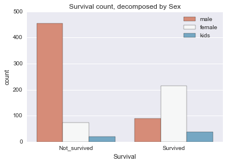

```python
plt.figure(1, figsize=(6,4))
ax=sns.countplot(x="Survived", hue='Sex', data=t_data, palette='RdBu');
ax.set(xlabel='Survival', title='Survival count, decomposed by Sex')
ax.set_xticklabels(["Not_survived", "Survived"])
ax.legend(labels = ["male", "female", "kids"])
plt.show()
```

For those survived, the number of males is comparable to the other 2 groups, although the overall survival rate of males is far lower than the other 2 groups,

We could also observe this problem from the following cross table.

```python
# I make a contingency table between the "Survived" and "Sex" variables.

Survived_Sex_cross_tab = pd.crosstab(index = t_data["Survived"],columns = t_data["Sex"], margins = True)

Survived_Sex_cross_tab.index = ["Not_Survived","Survived","up_down_margin"]
Survived_Sex_cross_tab.columns = ["Male","Female","Kids", "left_right_margin"]
Survived_Sex_cross_tab

# type(Survived_Sex_cross_tab)
```

|  | Male | Female | Kids | left_right_margin |
| --- | --- | --- | --- | --- |
| Not_Survived | 455 | 74 | 20 | 549 |
| Survived | 90 | 214 | 38 | 342 |
| up_down_margin | 545 | 288 | 58 | 891 |

If Sex did not have any influence on the survival rate, we would expect the survival rate to be uniformly distributedd across Sex.

To check the above point, I now adjust the survival rate of each Sex group by their respective fraction. I now check whether the adjusted survival rate is uniform. I use a simple chi-square goodness of fit, which suggests that the adjusted survival rate is not uniform.

```python
weight_of_Sex = (Survived_Sex_cross_tab.loc["up_down_margin"]/len(t_data)).iloc[:-1]

survival_rate_on_Sex = (Survived_Sex_cross_tab.loc["Survived"]/Survived_Sex_cross_tab.loc["up_down_margin"]).iloc[:-1]

(chisq_value, p_value) = stats.chisquare(100* weight_of_Sex * survival_rate_on_Sex)

print "H0: The adjusted survival rate is uniformly distributed across Sex."
print "H1: The adjusted survival rate is not uniformly distributed across Sex."
print "The p value {} suggests that at a 5% critical level, we reject H0.".format(p_value)
```

```
H0: The adjusted survival rate is uniformly distributed across Sex.
H1: The adjusted survival rate is not uniformly distributed across Sex.
The p value 0.000319324108861 suggests that at a 5% critical level, we reject H0.
```

I also ask the question whether age is an important factor which leads to the inferior survival rate among males. The following figures seem to suggest that it be not the case. Indeed, the two distributions look similar.

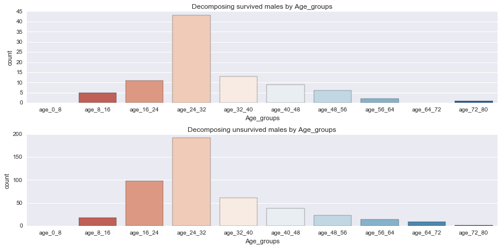

```python
plt.figure(1, figsize=(12,6))
plt.subplot(2,1,1)
ax=sns.countplot(x="Age_groups", data=t_data[(t_data["Sex"]==0) & (t_data["Survived"]==1)], palette='RdBu');
ax.set(xlabel='Age_groups', title='Age_groups_Count_Conditional_on_Survived');
ax.set(title='Decomposing survived males by Age_groups')
plt.subplot(2,1,2)
ax=sns.countplot(x="Age_groups", data=t_data[(t_data["Sex"]==0) & (t_data["Survived"]==0)], palette='RdBu');
ax.set(xlabel='Age_groups', title='Age_groups_Count_Conditional_on_unsurvived');
ax.set(title='Decomposing unsurvived males by Age_groups')
plt.tight_layout()
```

#### Furthermore, I conduct chi-square independence test to check the relationship between "Sex" and "Survival".

```python
# Now I do the chi-square independence test to confirm that the "Sex" variable has influence on the survival.
(test_stat, p_value, degree_of_f, expected_freq)=\
stats.chi2_contingency(pd.crosstab(t_data.Survived, t_data.Sex), correction = True)

print "H0: Survival is independent of Sex."
print "H1: Survival is not independent of Sex."
print "The p value {} suggests that at a 5% critical level, we reject H0.".format(p_value)
```

```
H0: Survival is independent of Sex.
H1: Survival is not independent of Sex.
The p value 1.05955122093e-62 suggests that at a 5% critical level, we reject H0.
```

The result implies that the variable Sex has impact on Survival.

#### Is there a relationship between the size of each Sex group and its corresonpding survival rate? The following result suggests it be not the case.

```python
stats.spearmanr((t_data.loc[t_data["Survived"]==1,"Sex"].value_counts()/t_data["Sex"].value_counts()).sort_index(), \
                t_data["Sex"].value_counts().sort_index())
```

```
SpearmanrResult(correlation=-0.5, pvalue=0.66666666666666674)
```

#### 3.1 Passenger class and survival rate

- Did passenger class influence survival rate? If so, Why exactly?

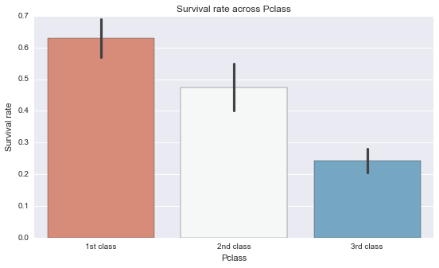

```python
# Bar plot on survival rate for each passenger class.
plt.figure(1, figsize=(9,5))
ax=sns.barplot(x="Pclass", y='Survived', data=t_data, palette='RdBu');
ax.set(xlabel='Pclass', ylabel = "Survival rate", title='Survival rate across Pclass')
ax.set_xticklabels(["1st class", "2nd class", "3rd class"])
plt.show()
```

```python
survival_rate_Pclass1 = \
t_data.loc[(t_data["Pclass"]==1) & (t_data["Survived"]==1), "Pclass"].value_counts()/\
t_data.loc[(t_data["Pclass"]==1), "Pclass"].value_counts()

survival_rate_Pclass2 = \
t_data.loc[(t_data["Pclass"]==2) & (t_data["Survived"]==1), "Pclass"].value_counts()/\
t_data.loc[(t_data["Pclass"]==2), "Pclass"].value_counts()

survival_rate_Pclass3 = \
t_data.loc[(t_data["Pclass"]==3) & (t_data["Survived"]==1), "Pclass"].value_counts()/\
t_data.loc[(t_data["Pclass"]==3), "Pclass"].value_counts()

print "The survival rate of Pclass 1 is {}.".format(survival_rate_Pclass1.iloc[0]) + "\n" + \
"The survival rate of Pclass 2 is {}.".format(survival_rate_Pclass2.iloc[0]) + "\n" + \
"The survival rate of Pclass 3 is {}.".format(survival_rate_Pclass3.iloc[0])
```

```
The survival rate of Pclass 1 is 0.62962962963.
The survival rate of Pclass 2 is 0.472826086957.
The survival rate of Pclass 3 is 0.242362525458.
```

The third class has the lowest survival rate. However, again, we also expect that the number of this third class is the largest, as illustrated by the following graph.

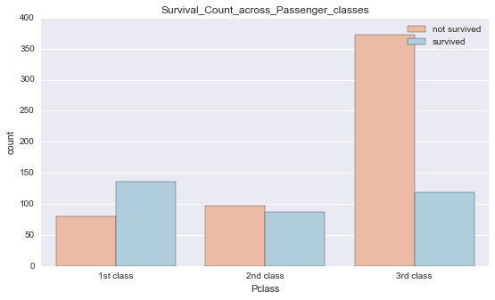

```python
# count plot
plt.figure(1, figsize=(9,5))
ax=sns.countplot(x="Pclass", hue='Survived', data=t_data, palette='RdBu');
ax.set(xlabel='Pclass', title='Survival_Count_across_Passenger_classes')
ax.legend(labels = ["not survived","survived"])
ax.set_xticklabels(["1st class", "2nd class", "3rd class"])
plt.show()
```

The figure above suggests that there seem to be far more passengers in the third class. (passengers may not be uniformly distributed across passenger classes.)

As in the previous subsection, I take into account of this size effect of the group, and adjust the group survival rate. I proceed as follows.

```python
# Again I make a contingency table between the "Survived" and "Pclass" variables.

Survived_Pclass_cross_tab = pd.crosstab(index = t_data["Survived"],columns = t_data["Pclass"], margins = True)

Survived_Pclass_cross_tab.index = ["Not_Survived","Survived","up_down_margin"]
Survived_Pclass_cross_tab.columns = ["Pclass_1","Pclass_2","Pclass_3", "left_right_margin"]
Survived_Pclass_cross_tab

# type(Survived_Sex_cross_tab)
```

|  | Pclass_1 | Pclass_2 | Pclass_3 | left_right_margin |
| --- | --- | --- | --- | --- |
| Not_Survived | 80 | 97 | 372 | 549 |
| Survived | 136 | 87 | 119 | 342 |
| up_down_margin | 216 | 184 | 491 | 891 |

```python
weight_of_Pclass = (Survived_Pclass_cross_tab.loc["up_down_margin"]/len(t_data)).iloc[:-1]

survival_rate_on_Pclass = (Survived_Pclass_cross_tab.loc["Survived"]/Survived_Pclass_cross_tab.loc["up_down_margin"]).iloc[:-1]

(chisq_value, p_value) = stats.chisquare(100* weight_of_Pclass * survival_rate_on_Pclass)

print "H0: The adjusted survival rate is uniformly distributed across Pclass."
print "H1: The adjusted survival rate is not uniformly distributed across Pclass."
print "The p value {} suggests that at a 5% critical level, we do not reject H0.".format(p_value)
```

```
H0: The adjusted survival rate is uniformly distributed across Pclass.
H1: The adjusted survival rate is not uniformly distributed across Pclass.
The p value 0.543672671868 suggests that at a 5% critical level, we do not reject H0.
```

The above shows that, if we take into account of the number of passengers travelling in each class, the survival rate of Pclass 3 is not statistically inferior to the other two classes.

Now I do the chi-square independence test to confirm that the "Plcass" variable has influence on the survival.

```python
(test_stat, p_value, degree_of_f, expected_freq)=\
stats.chi2_contingency(pd.crosstab(t_data.Survived, t_data.Pclass), correction = True)

print "H0: Survival is independent of Pclass."
print "H1: Survival is not independent of Pclass."
print "The p value {} suggests that at a 5% critical level, we reject H0.".format(p_value)
```

```
H0: Survival is independent of Pclass.
H1: Survival is not independent of Pclass.
The p value 4.5492517113e-23 suggests that at a 5% critical level, we reject H0.
```

Why is this the case? Maybe it has something to do with the Sex.

In the following two plots, we notice that it may be because there are unproportionately more males at the 3rd class who did not survive compared to the other two passenger classes.

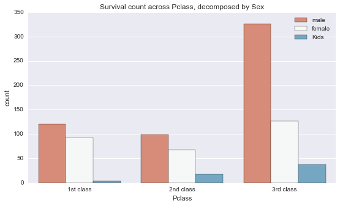

```python
# Countplot, by Sex
plt.figure(1, figsize=(9,5))
ax=sns.countplot(x="Pclass", hue = "Sex", data=t_data, palette='RdBu');
ax.set(xlabel='Pclass', title='Survival count across Pclass, decomposed by Sex')
ax.legend(labels = ["male","female", "Kids"])
ax.set_xticklabels(["1st class", "2nd class", "3rd class"])
plt.show()

# The above code could be also rewriten as follows. Check the difference.
# plt.figure(1, figsize=(9,5))
# ax=sns.factorplot(x="Pclass", hue = "Sex", data=t_data, palette='RdBu', kind = 'count');
# ax.set(xlabel='Pclass', title='Survival_Count_Based_on_Pclass')
# plt.show()
```

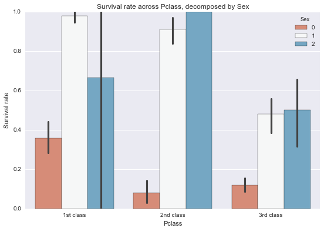

```python
# barplot shows the inferior survival rate of males at 3rd class.
plt.figure(1, figsize=(9,6))
ax=sns.barplot(x="Pclass", y='Survived', hue = "Sex", data=t_data, palette='RdBu');
ax.set(xlabel='Pclass', ylabel = "Survival rate", title='Survival rate across Pclass, decomposed by Sex')
# ax.legend(labels = ["male","female", "Kids"])
ax.set_xticklabels(["1st class", "2nd class", "3rd class"])
plt.show()
```

#### 3.2 Age groups and survival rate.

- How do survival rates vary for different age groups?

I start by plotting the survival rate for each age group.

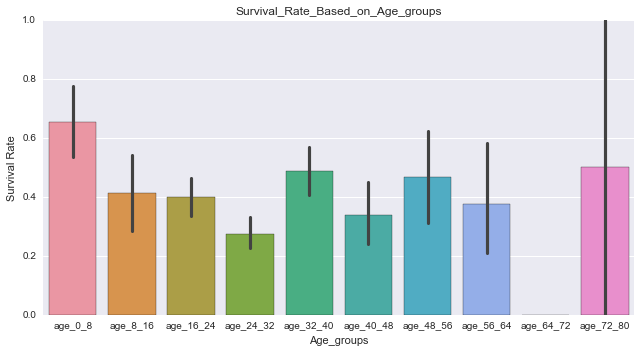

```python
plt.figure(1, figsize=(9,5))
ax=sns.barplot(x="Age_groups", y='Survived', data=t_data);
ax.set(xlabel='Age_groups', ylabel = "Survival Rate", title='Survival_Rate_Based_on_Age_groups')
# ax.legend(labels = ["Not_Survived","Survived"])
plt.tight_layout()
```

I decompose each age group by Sex, and draw the corresponding survival rate.

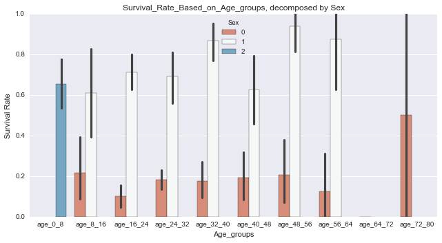

```python
plt.figure(1, figsize=(9,5))
ax=sns.barplot(x="Age_groups", y="Survived", hue='Sex', data=t_data, palette='RdBu');
ax.set(xlabel='Age_groups', ylabel = "Survival Rate", title='Survival_Rate_Based_on_Age_groups, decomposed by Sex')
# ax.legend(labels = ["Not_Survived","Survived"])
plt.tight_layout()
```

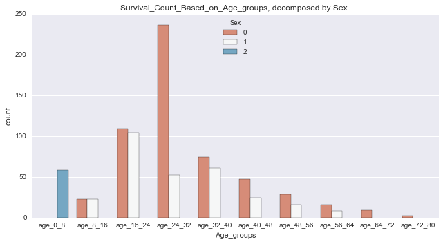

```python
plt.figure(1, figsize=(9,5))
ax=sns.countplot(x="Age_groups", hue='Sex', data=t_data, palette='RdBu');
ax.set(xlabel='Age_groups', title='Survival_Count_Based_on_Age_groups, decomposed by Sex.')
# ax.legend(labels = ["Not_Survived","Survived"])
plt.tight_layout()
```

I now do a chi-square independence test to examine the relationship between Age_groups and survival.

```python
# Now I do the chi-square independence test to confirm that the "Age_groups" variable
# has influence on the survival.
(test_stat, p_value, degree_of_f, expected_freq)=\
stats.chi2_contingency(pd.crosstab(t_data.Survived, t_data.Age_groups), correction = True)

print "H0: Survival is independent of Age_groups."
print "H1: Survival is not independent of Age_groups."
print "The p value {} suggests that at a 5% critical level, we reject H0.".format(p_value)
```

```
H0: Survival is independent of Age_groups.
H1: Survival is not independent of Age_groups.
The p value 3.92099103342e-07 suggests that at a 5% critical level, we reject H0.
```

#### 3.3 Family size and survival rate.

- Do families with larger size survive more often?
- Do people who travel together survive more often?

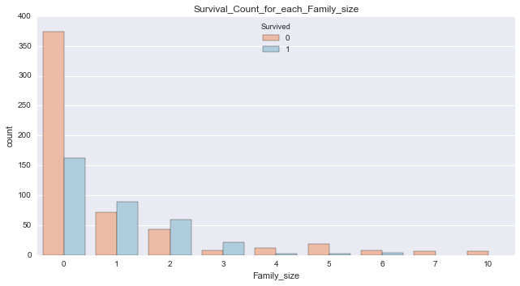

```python
# Countplot
plt.figure(1, figsize=(9,5))
ax=sns.countplot(x="Family_size", hue='Survived', data=t_data, palette='RdBu');
ax.set(xlabel='Family_size', title='Survival_Count_for_each_Family_size')
plt.tight_layout()
```

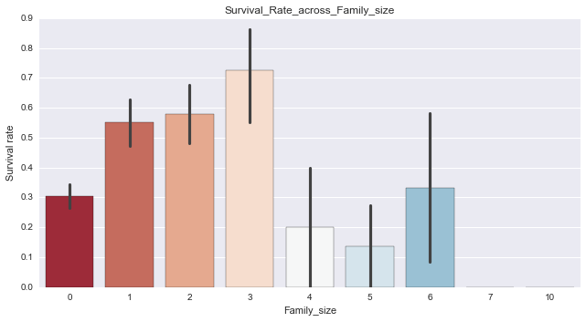

```python
# barplot
plt.figure(1, figsize=(9,5))
ax=sns.barplot(x="Family_size", y="Survived", data=t_data, palette='RdBu');
ax.set(xlabel='Family_size', ylabel="Survival rate", title='Survival_Rate_across_Family_size')
plt.tight_layout()
```

We notice that

1. people with family size 0 are less likely to survive. ((survival rate < 50%))
2. for family size ranging from 1 to 3, the survival rate is above 50%.
3. there is survival penalty (survival rate < 50%) for those families with a size greater than 3.

Why are there survival penalties? I now examine the families with size greater than 3. It turns out that most of these families are in the 3rd class.

```python
# t_data.loc[t_data["Family_size"] >=4].sort_values(["Pclass"], ascending = False)

t_data.loc[t_data["Family_size"]>=4, "Pclass"].value_counts()
```

```
3    54
1     6
2     2
Name: Pclass, dtype: int64
```

The following graph shows that number of youngsters in these families (size>=4) is unproportionately high.

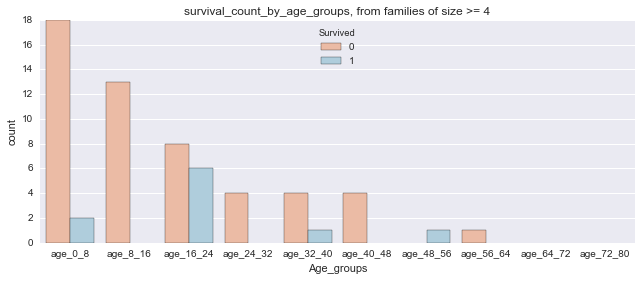

```python
plt.figure(1, figsize=(9,4))
ax=sns.countplot(x="Age_groups", hue= 'Survived', data=t_data.loc[t_data["Family_size"]>=4], palette='RdBu');
ax.set(xlabel='Age_groups', ylabel = 'count', title='survival_count_by_age_groups, from families of size >= 4')
plt.tight_layout()

# On average, neither the children nor the adults have higher survival rate.
```

I notice that the survival rate of kids ("age_group_0_8") in such families are especially low.

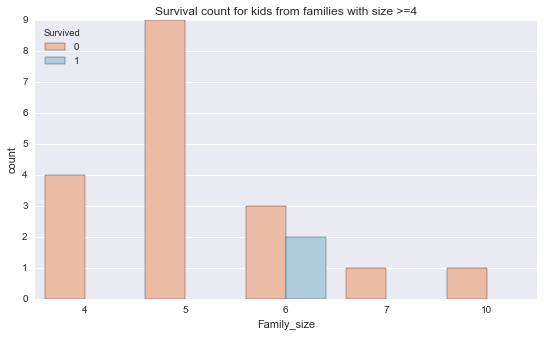

```python
# # I now show that kids within big family tend not to survive.
plt.figure(1, figsize=(9,5))
ax=sns.countplot(x="Family_size", hue='Survived', data=t_data[(t_data["Age_groups"] == "age_0_8") & (t_data["Family_size"] >= 4)], \
                 palette='RdBu');
ax.set(xlabel='Family_size', title='Survival count for kids from families with size >=4')
plt.show()
```

These kids were all from the third class.

```python
t_data[(t_data["Age_groups"] == "age_0_8") & (t_data["Family_size"] >= 4)].Pclass.value_counts()
```

```
3    20
Name: Pclass, dtype: int64
```

I now ask why do the families of size ranging from 0 to 3 have higher survival rate.

Decomposing by Pclass, I find that these families are distributed relatively uniformly across passenger classes.

```python
t_data.loc[(t_data["Family_size"]>0) & (t_data["Family_size"]<4), "Pclass"].value_counts()
```

```
3    113
1    101
2     78
Name: Pclass, dtype: int64
```

I then decompose them by Sex, I find that these families have slightly higher proportion of females, who in general survived more often.

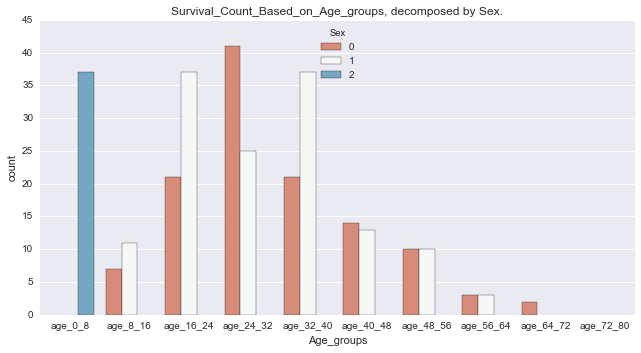

```python
plt.figure(1, figsize=(9,5))
ax=sns.countplot(x="Age_groups", hue='Sex', data=t_data[(t_data["Family_size"]>0) & (t_data["Family_size"]<4)], \
                 palette='RdBu');
ax.set(xlabel='Age_groups', title='Survival_Count_Based_on_Age_groups, decomposed by Sex.')
# ax.legend(labels = ["Not_Survived","Survived"])
plt.tight_layout()
```

At last, I ask whether people's survival rate is higher, if they travel together with at least one person.

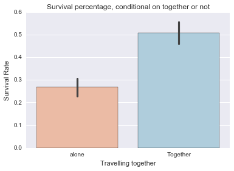

```python
plt.figure(1, figsize=(6,4))
ax=sns.barplot(x="Together", y='Survived', data=t_data, palette='RdBu');
ax.set(xlabel='Travelling together', ylabel = "Survival Rate", title='Survival percentage, conditional on together or not')
ax.set_xticklabels(["alone", "Together"])
plt.show()
```

The survival rate is considerably lower if one travels alone.

I decompose the people who travel alone by Sex, I find that male is the dominant sex at the alone group, who has the least survival rate among all Sexes.

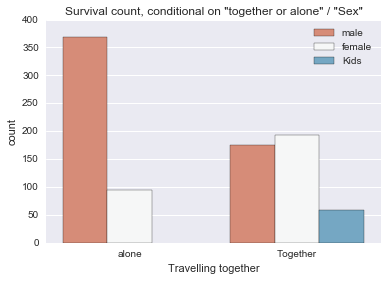

```python
plt.figure(1, figsize=(6,4))
ax=sns.countplot(x="Together", hue = "Sex", data=t_data, palette='RdBu');
ax.set(xlabel='Travelling together', title='Survival count, conditional on "together or alone" / "Sex"')
ax.set_xticklabels(["alone", "Together"])
ax.legend(labels = ["male", "female", "Kids"])
plt.show()
```

I also decompose the people who travel alone by Pclass, I find that 3rd class is dominant at the alone group, which is the class with the lowest survival rate.

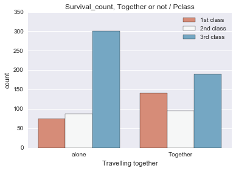

```python
plt.figure(1, figsize=(6,4))
ax=sns.countplot(x="Together", hue = "Pclass", data=t_data, palette='RdBu');
ax.set(xlabel='Travelling together', title='Survival_count, Together or not / Pclass')
ax.set_xticklabels(["alone", "Together"])
# ax.legend("Pclass", ["1st class", "2nd class", "3rd class"])
ax.legend(["1st class", "2nd class", "3rd class"])
plt.show()
```

The following code shows that there seem to be interaction effect from the variables Pclass and Sex:

Those who travel alone are very likely to be both male and in the 3rd class.

```python
# t_data.groupby(["Sex", "Pclass"]).\
# filter(lambda x: (x["Fare"].nunique()>1)).sort_values(["Ticket"])
t_data[t_data["Together"]==0].groupby(["Together", "Sex", "Pclass"]).size()
```

```
Together  Sex  Pclass
0         0    1          66
               2          59
               3         244
          1    1           9
               2          29
               3          57
dtype: int64
```

### 4. Summary

In this exercise, I have the following key observations in manipulating the data:

1. I decompose the "Name" variable and extract "prefix" to help me better fill the missing values in "Age".
2. Apart from familiy size, I find that "Ticket" number is a good measure for identifying whether people were travelling together.
3. I find that the "Fare" variable actually accounts for the price of one ticket, whereas many people who travel together can share one ticket. I thus divide the Fare by ticket size to find the price each individual paid.

I have the following results in investigating which factors may contribute to survival.

1. The survival rate of males is significantly lower than that of females and kids.
   - Male (16.51%) versus Female(74.31%) and Kids (65.52%)
2. Passengers in the 3rd class are less likely to survive.
   - Pclass_1 (62.96%), Pclass_2 (47.28%), Pclass_3 (24.24%)
   - This inferior survival rate is largely contributed by large number of males who travel alone in this class.
3. Survival rate is highest for children less than 8 years old. Females have dominant survival rate compared to males in each age group.
4. Family size
   - Families of size ranging from 1 to 3 have survival rates higher than 50%. These families have a good number of females (compared to that of males), which contribute to higher survial rates.
   - There is survival penalty for those families of size greater than 3. Most of these families travel in 3rd class.
5. People who travel alone survive less often. It is males who travael alone in the third class that contribute most to the inferior survival rate of this group.

#### 4.0 Further observations and limitations

The above data set does not allow us to access some important information for survival. For example, we do not know the time point at which a passenger realizes that he/she should escape; we do not know the exact distribution of cabines, each individual' whereabout and their activities at the time of crash; who were closest to the rescure boat; was evacuation organized efficiently; how many people did not survive because they tried to helped the others etc.

For future work, it would be also important to use more advanced methods such as random forests, PCA etc. to give more structured explanations based on the existing data.

### 5. Selected references

#### Graphs:

http://stackoverflow.com/questions/6541123/improve-subplot-size-spacing-with-many-subplots-in-matplotlib

http://stackoverflow.com/questions/31029560/plotting-categorical-data-with-pandas-and-matplotlib

https://scientificallysound.org/2016/06/09/matplotlib-how-to-plot-subplots-of-unequal-sizes/

http://www.cnblogs.com/wei-li/archive/2012/05/23/2506940.html

http://stackoverflow.com/questions/25239933/how-to-add-title-to-subplots-in-matplotlib

http://chrisalbon.com/python/seaborn_color_palettes.html

#### Tests:

https://hflog.wordpress.com/2014/04/01/how-to-perform-a-chi-squared-goodness-of-fit-test-in-python/

http://hamelg.blogspot.com/2015/11/python-for-data-analysis-part-25-chi.html

#### Groupby related:

http://stackoverflow.com/questions/20995196/python-pandas-counting-and-summing-specific-conditions

http://stackoverflow.com/questions/33823091/python-pandas-counting-the-frequency-of-a-specific-value-in-each-row-of-datafra